# Can You Cheat At Rock, Paper, Scissors?

## [Riddler Express](https://fivethirtyeight.com/features/can-you-cheat-at-rock-paper-scissors/)

Congratulations, you’ve made it to the final round of the Riddler Rock, Paper, Scissors.

The [rules](https://www.youtube.com/watch?v=rudzYPHuewc) are simple: Rock beats scissors, scissors beat paper, and paper beats rock. Moreover, the game is “sudden death,” so the first person to win a single round is immediately declared the grand champion. If there’s a tie, meaning both players choose the same object, then you simply play another round.

Fortunately, your opponent is someone you’ve studied well. Based on the motion of their arm, you can tell whether they will (1) play rock or paper with equal probability, (2) play paper or scissors with equal probability or (3) play rock or scissors with equal probability. (Every round falls into one of these three categories.)

If you strategize correctly, what are your chances of winning the tournament?

## Solution

Traditional *Rock, Paper, Scissors* is a symmetric and fair game. Both players have the same strategies, and over many games, the score of each player is zero.

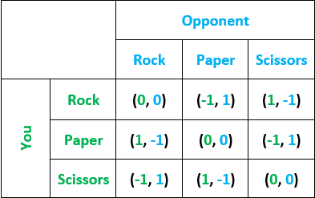

```python
from IPython.display import Image
Image(filename = 'RPS1.png')
```

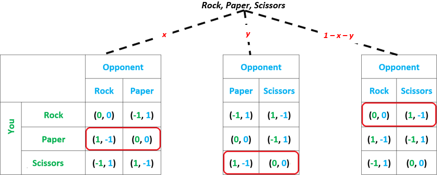

```python
Image(filename = 'RPS2.png')
```

Note that for each of the three possibilities of observing the opponent’s arm, there is an optimal strategy, that is, at best half the time you will win, and at worse, half the time you will tie. Combining all three possibilities for any round,

$$P_{win} = x \Big(\frac{1}{2} \Big) + y \Big(\frac{1}{2} \Big) + (1-x-y) \Big(\frac{1}{2} \Big) = \frac{1}{2}$$$$P_{tie} = x \Big(\frac{1}{2} \Big) + y \Big(\frac{1}{2} \Big) + (1-x-y) \Big(\frac{1}{2} \Big) = \frac{1}{2}$$

## Answer

This leads to the probability of winning the tournament to be,

$$P_{tournament} = \frac{1}{2} + \frac{1}{4} + \frac{1}{8} + ⋯ = 1$$

#### 2020.08.03 (Converted to Notebook on 2020.09.23)